# Functional Programming - Midterm

Anwesha Guha, Errol Kaylor, Cassie Malcom, Manuel Vazquez

4/5/2022

# Part A: Data

### 20 points

The following function downloads data from the Oregon Department of education website on the number of students who scored in each performance category on the statewide assessment by race/ethnicity for every school in the state. It takes one argument, `year`, which must be a two digit integer from 15 to 18 (representing the 2014-15 to 2017-18 school years). It actually won’t work on later years because the file structure changed and I wanted to keep the function simple.

**NOTE:** This function uses the `glue` function from the package of the same name. If you do not already have this package installed, please first install it with `install.packages("glue")`. It also uses `{rio}` for the import, which you should already have installed, but if not, install that first too.

```r
download_file <- function(year) {
  link <- glue::glue("https://www.oregon.gov/ode/educator-resources/assessment/TestResults20{year}/pagr_schools_ela_raceethnicity_{year-1}{year}.xlsx")
  rio::import(link, setclass = "tibble", na = c("-", "--", "*"))
}
```

1. (10 points) Use the function above to download *all* of the data from the 2014-15 to 2017-18 school years and bind it into a single data frame, **using a single function** (i.e., one line of code). Note, this may take a minute or two to run, depending on your Internet speed.

```r
assessments <- map_dfr(15:18, ~download_file(.x))
```

Conduct some basic data cleaning to make your data file look like the following.

- Filter for only student groups coded as `"White"` or `"Hispanic/Latino"`.

```r
# assessments_clean <- map(assessments, ~filter(., `Student Group` == "White" | `Student Group` == "Hispanic/Latino"))

assessments_clean <- assessments %>%
  filter(`Student Group`== "Hispanic/Latino" | `Student Group` == "White")
```

- Select variables related to the number of students in each of the levels (1:4), and not percentages or collapsed levels.

```r
#assessments_clean <- map_dfr(assessments_clean, ~select(., -contains(c("percent", "rate", "proficient"))))

assessments_clean <- assessments_clean %>%
  select(-contains(c("percent","rate","proficient")))
```

- Remove any row that has missing data in any of the *n* variables

```r
#assessments_clean <- map(assessments_clean, ~drop_na(.x, contains("number")))

assessments_clean <- assessments_clean %>%
  drop_na(contains("number")) %>%
  pivot_longer(cols = 9:12,
               names_to = "level",
               names_prefix = "Number Level",
               values_to = "n") %>%
  janitor::clean_names()

assessments_clean
```

```
## # A tibble: 90,576 x 11
##    academic_year district_id district     school_id school subject student_group
##    <chr>               <dbl> <chr>            <dbl> <chr>  <chr>   <chr>
##  1 2014-2015            2113 Adrian SD 61       707 Adria~ Englis~ Hispanic/Lat~
##  2 2014-2015            2113 Adrian SD 61       707 Adria~ Englis~ Hispanic/Lat~
##  3 2014-2015            2113 Adrian SD 61       707 Adria~ Englis~ Hispanic/Lat~
##  4 2014-2015            2113 Adrian SD 61       707 Adria~ Englis~ Hispanic/Lat~
##  5 2014-2015            2113 Adrian SD 61       707 Adria~ Englis~ Hispanic/Lat~
##  6 2014-2015            2113 Adrian SD 61       707 Adria~ Englis~ Hispanic/Lat~
##  7 2014-2015            2113 Adrian SD 61       707 Adria~ Englis~ Hispanic/Lat~
##  8 2014-2015            2113 Adrian SD 61       707 Adria~ Englis~ Hispanic/Lat~
##  9 2014-2015            2113 Adrian SD 61       707 Adria~ Englis~ Hispanic/Lat~
## 10 2014-2015            2113 Adrian SD 61       707 Adria~ Englis~ Hispanic/Lat~
## # ... with 90,566 more rows, and 4 more variables: grade_level <chr>,
## #   number_of_participants <dbl>, level <chr>, n <dbl>
```

2. (10 points) Sum the *n* across grades and school for each district within each academic year, student group, and level. Calculate the number of schools (unique schools listed) for each district. Also move your data to a wider format where the student groups become new columns, filled by the district n. Remove districts that did not report numbers for one or both student groups (i.e., drop missing data from the new columns). Your data frame should look like the below.

```r
schools <- assessments_clean %>%
  group_by(district,academic_year) %>%
  summarize(n_schools = n_distinct(school))
assessment_agg <- assessments_clean %>%
  group_by(district,academic_year, level, student_group) %>%
  summarize(n_students = sum(n)) %>%
  pivot_wider(names_from = student_group,
              values_from = n_students) %>%

  left_join(schools) %>%
  janitor::clean_names() %>%
  drop_na(contains("hispanic"))
head(assessment_agg)
```

```
## # A tibble: 6 x 6
## # Groups:   district, academic_year, level [6]
##   district     academic_year level hispanic_latino white n_schools
##   <chr>        <chr>         <chr>           <dbl> <dbl>     <int>
## 1 Adrian SD 61 2014-2015     " 1"                6     8         1
## 2 Adrian SD 61 2014-2015     " 2"                6    17         1
## 3 Adrian SD 61 2014-2015     " 3"                6    23         1
## 4 Adrian SD 61 2014-2015     " 4"                1    22         1
## 5 Adrian SD 61 2015-2016     " 1"                5     4         2
## 6 Adrian SD 61 2015-2016     " 2"                3    15         2
```

# Part B: Achievement disparities

### 40 points

If you have not already done so, please install the [{gapr}](https://github.com/datalorax/gapr) package using the following code:

```r
remotes::install_github("datalorax/gapr")
```

The {gapr} package includes, at the moment, one function, `estimate_v()`, which estimates the average difference between two distributions in terms of an effect size when the only data available are counts within bins (for more information, see [Ho & Reardon, 2012](https://journals.sagepub.com/doi/10.3102/1076998611411918)). The nice thing about this approach is that we’re able to obtain the effect size of average differences in achievement between two groups of students *as if we had the full, student level data* even though we just have counts within bins (performance levels).

The `estimate_v` function takes 3 arguments in the following order: (1) the data frame including the counts for each group, (2) a character string stating the name of the column with the counts for the reference group, and (3) a character string stating the name of the column with the counts for the focal group.

To estimate the average achievement difference between students coded Hispanic/Latino versus White for the first school district in the first year in our data, we would run the following

```r
test <- assessment_agg[1:4, ] %>% # just first four rows for first district
  estimate_v("white", "hispanic_latino") # columns for ref/focal groups

str(test)
```

```
## 'data.frame':    1 obs. of  3 variables:
##  $ auc : num 0.282
##  $ v   : num -0.814
##  $ v_se: num 0.0728
```

```r
# Can extract the components?
```

We can see that students coded Hispanic/Latino scored, on average, about 0.81 standard deviations below students coded White within this school district for this year.

1. (10 points) Estimate the average achievement differences in terms of an effect size for every school district in the state that reported data on both student groups (i.e., using the data we created above), for each academic year. Conduct this analysis twice, once using `group_by() %>% nest() map()` and once using `nest_by() %>% summarize()`.

Method 1: using `group_by() %>% nest() map()`

```r
method1 <- assessment_agg %>%
  group_by(district, academic_year) %>%
  nest() %>%
  mutate(m1 = map(data, ~estimate_v(.x[1:4, ], "white","hispanic_latino")),
         achieve_diff = map(m1, 2)
         ) %>%
  unnest(achieve_diff)
method1
```

```
## # A tibble: 484 x 5
## # Groups:   district, academic_year [484]
##    district     academic_year data             m1           achieve_diff
##    <chr>        <chr>         <list>           <list>              <dbl>
##  1 Adrian SD 61 2014-2015     <tibble [4 x 4]> <df [1 x 3]>       -0.814
##  2 Adrian SD 61 2015-2016     <tibble [4 x 4]> <df [1 x 3]>       -1.40
##  3 Adrian SD 61 2016-2017     <tibble [4 x 4]> <df [1 x 3]>       -0.278
##  4 Adrian SD 61 2017-2018     <tibble [4 x 4]> <df [1 x 3]>       -0.742
##  5 Amity SD 4J  2014-2015     <tibble [4 x 4]> <df [1 x 3]>       -0.301
##  6 Amity SD 4J  2015-2016     <tibble [4 x 4]> <df [1 x 3]>       -0.243
##  7 Amity SD 4J  2016-2017     <tibble [4 x 4]> <df [1 x 3]>       -0.594
##  8 Amity SD 4J  2017-2018     <tibble [4 x 4]> <df [1 x 3]>       -0.111
##  9 Annex SD 29  2016-2017     <tibble [4 x 4]> <df [1 x 3]>        0.313
## 10 Ashland SD 5 2014-2015     <tibble [4 x 4]> <df [1 x 3]>       -0.703
## # ... with 474 more rows
```

Method 2: using `nest_by() %>% summarize()`

```r
method2 <- assessment_agg %>%
  ungroup() %>%
  nest_by(district, academic_year) %>%
  summarize(ach_dif2 = list(estimate_v(data, "white", "hispanic_latino"))) %>%
  unnest(ach_dif2)
```

```
## Warning in mle2(BMNLLNew, start = parameters, method = "BFGS", data = list(fi =
## fpCounts, : couldn't invert Hessian
```

```r
method2
```

```
## # A tibble: 484 x 5
## # Groups:   district, academic_year [484]
##    district     academic_year   auc      v   v_se
##    <chr>        <chr>         <dbl>  <dbl>  <dbl>
##  1 Adrian SD 61 2014-2015     0.282 -0.814 0.0728
##  2 Adrian SD 61 2015-2016     0.161 -1.40  0.114
##  3 Adrian SD 61 2016-2017     0.422 -0.278 0.381
##  4 Adrian SD 61 2017-2018     0.300 -0.742 0.109
##  5 Amity SD 4J  2014-2015     0.416 -0.301 0.0204
##  6 Amity SD 4J  2015-2016     0.432 -0.243 0.0210
##  7 Amity SD 4J  2016-2017     0.337 -0.594 0.0244
##  8 Amity SD 4J  2017-2018     0.469 -0.111 0.0207
##  9 Annex SD 29  2016-2017     0.588  0.313 0.449
## 10 Ashland SD 5 2014-2015     0.310 -0.703 0.0168
## # ... with 474 more rows
```

Note, on my computer these took about 40 seconds per analysis. It will likely take a bit longer for you, but shouldn’t take *too* long. You may get a warning. Just go ahead and ignore that for now.

2. (5 points)

Reproduce the following plot to confirm that the estimates are equivalent across methods.

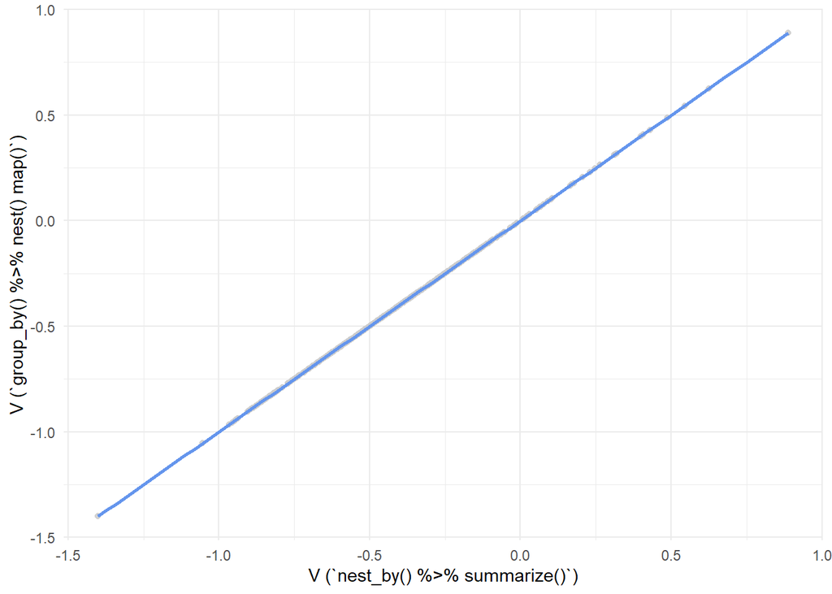

```r
#replace method1_b with method2 result when ready - Done, Cassie
# method2 < method2 # I'm not sure if we want to replace one df with another. I did a join instead. I redid this section - Anwesha
combined_methods <- left_join(method1, method2, by = c("district", "academic_year"))
#
# str(method2)
# map2(method1,method2,~ggplot(data = .x,aes(x=achieve_diff,y=achieve_diff))) #intention is to cycle through metho1 and method2 objects, and create geom_points using achieve_diff from each observation.
# str(method2$achieve_diff)


combined_methods %>%
  ggplot(aes(x = v, # method 2 on x axis
             y = achieve_diff)) + # method 1 on y axis
  geom_point(color = "gray80",
             alpha = .85) +
  geom_smooth(color = "cornflowerblue",
              alpha = .9) +
  theme_minimal() +
  labs(x = "V (`nest_by() %>% summarize()`)",
       y = "V (`group_by() %>% nest() map()`)")
```

```r
#method1 %>%  # Cassie's effort at Part B Plot 2 - still throwing an error
#  rename(v1 = achieve_diff) %>%
#  left_join(method2) %>%
#  rename(v2 = v) %>%
#  ggplot(aes(v2, v1)) +
#  geom_point() +
#  geom_line(color = "cornflowerblue") +
#  xlab("nest_by") +
#  ylab("group_by") +
#  theme_minimal()
```

Hint: You need to select unique *districts*. You may want to try something like the following:

Method 1 -

```r
district_school_count <- assessment_agg %>%
  group_by(district) %>%
  summarize(school_count = min(n_schools)) %>%
  mutate(school_count_label = glue(
    "Note: District included {school_count} school(s)"),
    district_label = glue("Achievement Gap Estimates: {district}")
  )


#took the min value to account for school closures
dists <- unique(method1$district)[1:100] # Updated this code with our dataframe labels - Cassie # changed to method 1 - AG


district_differences <- method1 %>%
  filter(district %in% dists) %>%
  left_join(district_school_count, by = "district") %>%
  mutate(v_se = map_dbl(m1,3),
         Color = ifelse(achieve_diff < 0, "#d35cff","#5ca3ff"))


#dists_of_interest <- method1 %>%
#  filter(district %in% dists)

#dist_1 <- dists_of_interest %>%
#  filter(district =="Adrian SD 61") %>%
#  mutate(v_se = map_dbl(m1,3))
#        label = map_chr(glue("District included {~.1} schools."),2)) #bringing se values out to the row level

#dist_1[3]


# Method 1

#dist_1 %>% ggplot(aes(academic_year,achieve_diff))+
# geom_line()+
#  geom_errorbar(aes(ymin = achieve_diff-v_se,
#                    ymax=achieve_diff+v_se))+
#  geom_hline(yintercept=0,
#             color = "red")+
#  geom_point(data = filter(dist_1,achieve_diff<0),
#             color = "#d35cff")+
#  geom_point(data = filter(dist_1,achieve_diff>0),
#             color = "#5ca3ff")+
#  labs(title = glue("Achievement Gap Estimates: {dist_1[[1]]}"),
#       subtitle = "Negative values indicate White students have higher average achievement\nPositive Values indicate Hispanic/Latino students have higher average achievement",
#       caption = glue("Note: District included {dist_1[[3]][[1]][[4]]} school(s)"),
#       x="School Year",
#       y= "Average achievement difference (SD units)")


#why am I getting the discrete value and continuous scale error?!?! I am going bonkers
#not sure what change Anwesha made to have this code start working, but it makes me joyous)


#EK: creating the caption is still in progress
#final_plots <- district_differences %>%
#  group_by(district_label,school_count_label) %>%
#  mutate(
#    plots = pmap(list(district_label,school_count_label,data), #~{
#    ggplot(..3,aes(academic_year,achieve_diff))+
#      geom_errorbar(aes(ymin = achieve_diff-v_se,
#                    ymax=achieve_diff+v_se))+
#      geom_hline(yintercept=0,
#             color = "red")+
#      geom_point(aes(color = Color))+
#      labs(title = ..1,
#           subtitle = "Negative values indicate White students have higher average achievement\nPositive Values indicate Hispanic/Latino students have higher average achievement",
#           x="School Year",
#           y= "Average achievement difference (SD units)",
#               caption = ..2)
#  })
#)
#final_plots$plots[[1]]
#final_plots$plots
```

Method 2 -

```r
#test_plots <- head(district_differences, 10)

#plot2 <- test_plots %>%
#  group_by(district, school_count) %>%
#  nest() %>%
#  mutate(
#    plot = pmap(list(district, data, school_count), ~{
#      ggplot(data = ., aes(x = academic_year, y = v)) +
#                  geom_errorbar(ymin = v - v_se, ymax = v + v_se) +
#                  geom_line() +
#                  geom_hline(yintercept=0,
#                             color = "red")
#    }
#    )
#  )



#method 2, generating plots with nest_by

final_plots2 <- district_differences %>%
  ungroup() %>%
  nest_by(school_count_label,district_label) %>%
  mutate(
    plots = list(
      ggplot(data, aes(academic_year,achieve_diff))+
        geom_hline(yintercept=0,
                   color = "red")+
        geom_errorbar(aes(ymin=achieve_diff-v_se,
                          ymax=achieve_diff+v_se))+
        geom_point(aes(color = Color))+
        geom_line(aes(y=achieve_diff))+
        guides(fill = "none")+
        labs(
          title = district_label,
          subtitle = "Negative values indicate <span style ='color:#d35cff'>White</span> students have higher average achievement\nPositive Values indicate <span style = 'color:#5ca3ff'>Hispanic/Latino</span> students have higher average achievement",
           x="School Year",
           y= "Average achievement difference (SD units)",
               caption = school_count_label
        )+
        theme(legend.position="none")
        )
  )
```

**Extra Credit:** For up to one point extra credit, create a third set that “staples together” each of the preceding pairs of plots (i.e., to confirm that the plots were produced identically by both methods).

4. (10 points) Save the plots into a “plots” directory. Make sure the file names are meaningful.

Create a directory

```r
# Cassie's working on this section.
# filenames <- here::here("plots", paste0("cyl", names(by_cyl), ".png"))

# filenames

#OR fs::dir_create(here::here("plots", "subfolder name"))
```

Save plots

```r
# Cassie's working on this section - will update when graphs ready.

fs::dir_create(here("plots","foo"))
files <- str_replace_all(
  tolower(final_plots2$district_label),
  " ",
  "-"
)
paths<- here("plots","foo",glue("{files}.png"))

walk2(paths,final_plots2$plots,ggsave,
      width= 9.5,
      height = 6.5,
      dpi = 500)
```

[output not shown]

[output cut: 145 more lines]

[output not shown]

```r
#final_plots2 %>%
#  ungroup() %>%
#  mutate(path = paths) %>%
#  rowwise() %>%
#  summarize(
#    ggsave(
#      path,
#      plots
#    )
#  )
#newspapers <- str_replace_all(
#tolower(final_plots$newspaper),
#" ",
#"-"
#) paths <- here::here(
#"plots",
#"pulitzers",
#glue("{newspapers}.png")
#)
```

**HINTS**

- You don’t have to use a loop to create the file names (maybe give `{glue}` a try? Otherwise `paste` or `paste0` will work fine).
- When working with the code, limit the number of plots you’re saving to, say, the first five to make sure it works before running it on all plots.